# Лабораторная работа

Поиск файлов. Перенаправление ввода-вывода. Просмотр запущенных процессов

Дудырев Г. А.

Российский университет дружбы народов, Москва, Россия

11 марта 2023

## Цель

Ознакомление с инструментами поиска файлов и фильтрации текстовых данных. Приобретение практических навыков: по управлению процессами (и заданиями), по проверке использования диска и обслуживанию файловых систем.

## Ход выполнения

Первым делом нам необходимо, записать все файлы из каталога /etc и домашнего каталога в файл file.txt, для этого воспользуемся командой find с опцией -type f

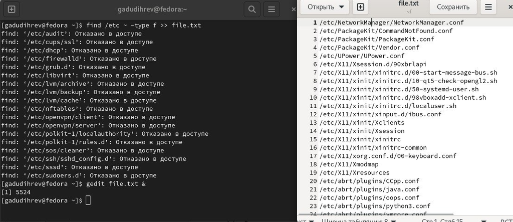

## Ход выполнения

Теперь из файла file.txt нам надо найти все файлы, у которых расширение .conf, для этого применим команду grep и перенаправим вывод в файд conf.txt

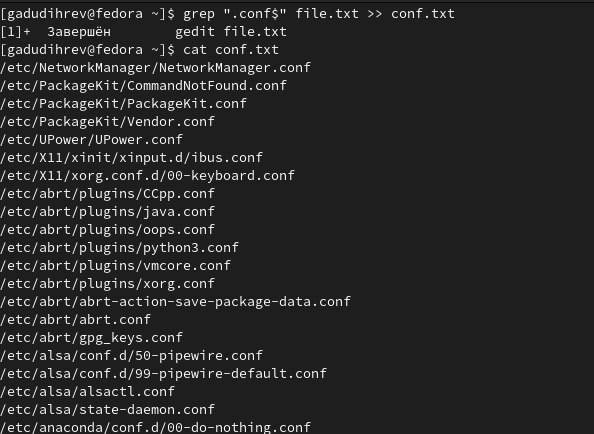

## Ход выполнения

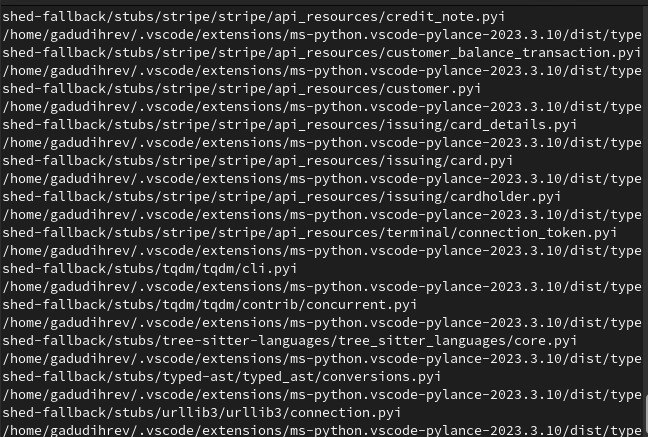

## Ход выполнения

Запустим в фоновом режиме процесс, который будет записывать в файл ~/logfile файлы, имена которых начинаются с log. Для этого воспользуемся командой find и укажем в конце &, что запустит процесс в фоновом режиме. Удалим этот файл командой rm

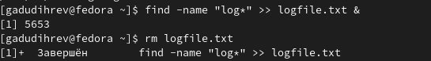

## Ход выполнения

Запустим gedit в фоновом режиме, используя команду ps, конвейер и grep, узнаем индентификатор процесса, также это можно сделать используя команду jobs. Теперь с помощью команды kill и индентификатора завершим этот процесс

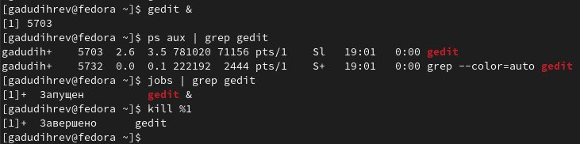

## Ход выполнения

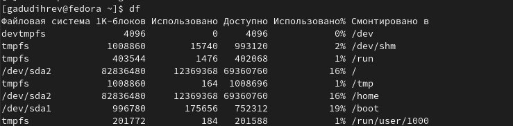

## Ход выполнения

Команда du показывает число килобайт, используемое каждым файлом или каталогом

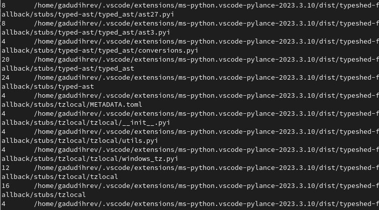

## Выводы

Были получены навыки работы с инструментами поиска файлов и фильтрации текстовых данных, а также по управлению процессами (и заданиями), по проверке использования диска и обслуживанию файловых систем.